# An Analysis of Factors Influencing Pet Adoption

DSCI 415 Final Report

Matthew Barclay

12/16/2020

# Introduction

Animal shelters across the United States receive nearly 6.5 million animals per year and are tasked with housing, feeding, and returning animals to owners or adopting these animals out. Invariably, with cost and size constraints many shelters must resort to euthanization to avoid overcrowding. According to the ASPCA, 1.5 million animal euthanizations take place in animal shelters. Reducing the time spent in a shelter by an animal and conversely increasing the adoptions of animals spending a large amount of time in the shelter may be a solution to reduce the volume of euthanizations.

Using shelter data to analyze the factors that influence the time spent in a shelter before adoption may offer insight to assist shelter staff. By understanding the factors which increase time spent in the shelter, staff may be able to identify animals at risk of long stays and focus more attention to them to reduce their time until adoption. The goal of this analysis is to report the most influential factors affecting time spent in a shelter.

All data were retrieved from the public database data.AustinTexas.gov which reports all animal intakes and outcomes for the Austin Animal Center since October, 2013. This shelter is a “No Kill” shelter and therefore animals leave the shelter by adoption, transfer to rescues, or returned to owners. Because the shelter does not engage in euthanizations, the data are not influenced by overcrowding and the time elapsed represents the true time until adoption for the animals. The data includes information on the intake type, intake condition, animal type, animal sex, outcome type, foster status, animal age, and the time spent in the shelter. The majority of this data are categorical, with animal age and time elapsed being the only numeric data.

The data will be analyzed using both multiple linear regression (MLR) and the Cox proportional hazards models. These models will be used to give insight on the factors influencing pet adoption.

# Methods

## Models

### MLR

A multiple linear regression model was fit to explain the time spent in the shelter from the data collected on the animal. The response variable Time.Elapsed was highly right skewed and required a log transformation. The log transformation was necessary as it fixed the distribution of the residuals to fit linear model assumptions.

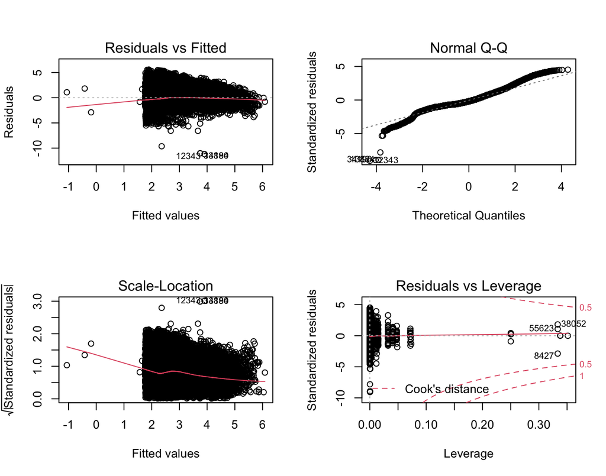

After log the transformations, the model much more closely follows the assumptions for a linear model.

Forward stepwise search was used to select the optimal linear model using both AIC and BIC, with both selecting the following model:

log(Time.Elapsed) ~ Outcome.Subtype + Intake.Type + Age.upon.Intake + Animal.Type.x + Intake.Condition + Sex.upon.Intake + Age.upon.Intake:Animal.Type.x

To test for multicollinearity, the variable inflation factor (VIF) was tested and all factors were below the reasonable level.

### Proportional Hazards

In addition to the MLR model, a Cox proportional hazards model was fit, as it is a strong method for determining the influence a factor, or “risk”, has on an event happening. As the dataset contains only adopted animals, it was not necessary to censor the data because all entries have the “event” of adoption. The proportional hazards model was selected via stepwise forward AIC. The stepwise algorithm selected the same factors as MLR:  
Intake.Type + Intake.Condition + Animal.Type.x + Sex.upon.Intake + Age.upon.Intake + Outcome.Subtype + Animal.Type.x *Age.upon.Intake

Similar to MLR, the response variable is log transformed. While this model works well to highlight the effect of each factor, it may be inaccurate as the proportionality assumption, indicating that significant conclusions cannot be drawn using this model. As this report is focused only on suggesting possible effects, the significance of the model is not as important as its effects, and therefore should be used but with a grain of salt.

### Mixed Effects Modelling

A mixed effects model was considered for use, but the dataset did not contain any usable information on sub-groupings and therefore was not possible to be used. If data on groupings such as zip code of adopters, adopter age group, or found location were available, it would be interesting to use a mixed effects model to explain more of the variance.

# Results

### MLR

| Observations | Residual Std. Error | $R^2$ | Adjusted $R^2$ |
| --- | --- | --- | --- |
| 54102 | 1.233 | 0.2714 | 0.2711 |

### Proportional Hazards

|  | coef | se(coef) | Pr(>\|z\|) |
| --- | --- | --- | --- |
| **Outcome.SubtypeBarn** | 0.5131 | 0.5824 | 0.3783 |
| **Outcome.SubtypeFoster** | -0.8145 | 0.01133 | 0 |
| **Outcome.SubtypeOffsite** | -0.1252 | 0.05288 | 0.01789 |
| **Intake.TypeEuthanasia Request** | -0.2318 | 0.2863 | 0.4182 |
| **Intake.TypeOwner Surrender** | 0.003312 | 0.101 | 0.9738 |
| **Intake.TypePublic Assist** | -0.754 | 0.1049 | 6.542e-13 |
| **Intake.TypeStray** | -0.2236 | 0.1007 | 0.02638 |
| **Age.upon.Intake** | -0.0007424 | 6.05e-05 | 1.292e-34 |
| **Animal.Type.xDog** | 0.2795 | 0.01112 | 2.607e-139 |
| **Intake.ConditionBehavior** | -0.3291 | 0.5115 | 0.52 |
| **Intake.ConditionFeral** | -0.5697 | 0.2286 | 0.0127 |
| **Intake.ConditionInjured** | -0.7589 | 0.11 | 5.332e-12 |
| **Intake.ConditionMedical** | -0.2934 | 0.2431 | 0.2274 |
| **Intake.ConditionNormal** | -0.4443 | 0.1074 | 3.519e-05 |
| **Intake.ConditionNursing** | -0.8549 | 0.1124 | 2.909e-14 |
| **Intake.ConditionOther** | -0.7489 | 0.1599 | 2.822e-06 |
| **Intake.ConditionPregnant** | -1.039 | 0.2092 | 6.8e-07 |
| **Intake.ConditionSick** | -0.6004 | 0.113 | 1.077e-07 |
| **Sex.upon.IntakeIntact Male** | -0.02865 | 0.01009 | 0.004531 |
| **Sex.upon.IntakeNeutered Male** | -0.1588 | 0.01531 | 3.158e-25 |
| **Sex.upon.IntakeSpayed Female** | -0.152 | 0.0156 | 1.899e-22 |
| **Sex.upon.IntakeUnknown** | 2.86 | 0.5775 | 7.369e-07 |
| **Age.upon.Intake:Animal.Type.xDog** | -0.0008301 | 7.495e-05 | 1.662e-28 |

It is possible to analyze the differences within a categorical variable in a plot, where reaching a survival of zero means every animal has been adopted.

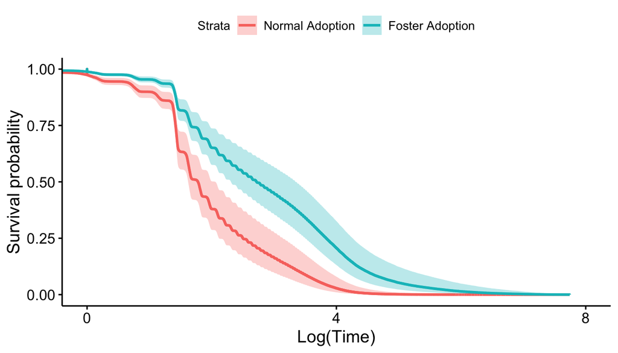

This plot shows that fostered animals are adopted out at a slower rate than ordinary adoptions and therefore spend more time in the shelter.

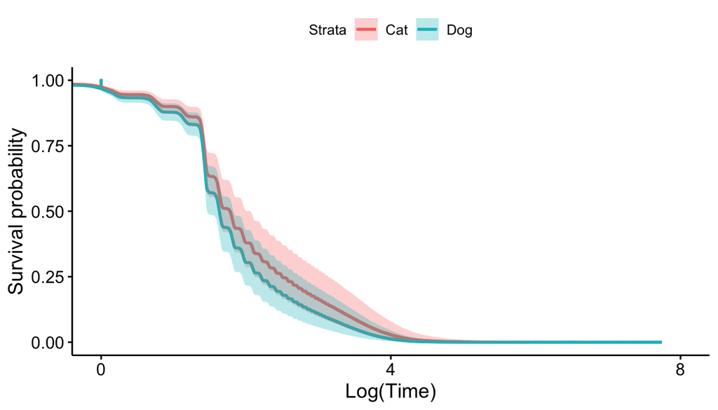

Although within the confidence intervals, cats spent a slightly longer time in the shelter than dogs.

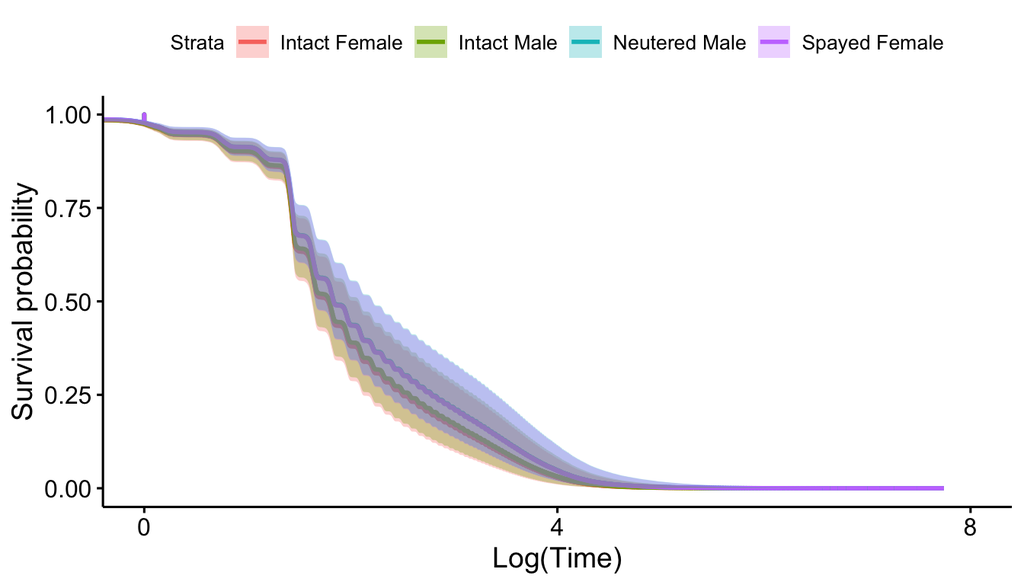

# Discussion

By analyzing the coefficients from both models, it is possible to identify similarities which indicate a factor is significant in practice. Therefore, shelter staff should use this to focus adoptions on animals which have one or more factors that indicate long stay times.

This data is from only one shelter and therefore may not be representative for other shelters. However, the differing preferences of adopters is a possible future point of research that may explain more about the time spent in the shelter.

Finally, it would be helpful to have more data on each animal, such as weight, size, personality, and ability to get along with other animals. Although these data were not collected by the shelter, it may allow the models to explain more of the variance in the time spent in the shelter until adoption.